# Predicting Customer Churn: Logistic Regression vs. Lasso

Betty Rudolf

2026-10-23

```r
# install.packages(c("modeldata", "glmnet", "caret", "pROC"))
library(modeldata)
library(glmnet)
library(pROC)
library(caret)

knitr::opts_chunk$set(echo = TRUE, message = FALSE, warning = FALSE)
```

# 1. Question and data

The business question is which customers are about to leave, so that the company can contact them before they do (for example with a discount or a call). A customer who leaves is lost revenue, whereas a retention offer to a customer who would have stayed only costs the offer. Missing a churner is therefore the more expensive mistake. A useful model should find as many churners as possible without flagging too many loyal customers.

```r
churn <- modeldata::mlc_churn
dim(churn)
```

```
## [1] 5000   20
```

```r
str(churn)
```

```
## tibble [5,000 × 20] (S3: tbl_df/tbl/data.frame)
##  $ state                        : Factor w/ 51 levels "AK","AL","AR",..: 17 36 32 36 37 2 20 25 19 50 ...
##  $ account_length               : int [1:5000] 128 107 137 84 75 118 121 147 117 141 ...
##  $ area_code                    : Factor w/ 3 levels "area_code_408",..: 2 2 2 1 2 3 3 2 1 2 ...
##  $ international_plan           : Factor w/ 2 levels "no","yes": 1 1 1 2 2 2 1 2 1 2 ...
##  $ voice_mail_plan              : Factor w/ 2 levels "no","yes": 2 2 1 1 1 1 2 1 1 2 ...
##  $ number_vmail_messages        : int [1:5000] 25 26 0 0 0 0 24 0 0 37 ...
##  $ total_day_minutes            : num [1:5000] 265 162 243 299 167 ...
##  $ total_day_calls              : int [1:5000] 110 123 114 71 113 98 88 79 97 84 ...
##  $ total_day_charge             : num [1:5000] 45.1 27.5 41.4 50.9 28.3 ...
##  $ total_eve_minutes            : num [1:5000] 197.4 195.5 121.2 61.9 148.3 ...
##  $ total_eve_calls              : int [1:5000] 99 103 110 88 122 101 108 94 80 111 ...
##  $ total_eve_charge             : num [1:5000] 16.78 16.62 10.3 5.26 12.61 ...
##  $ total_night_minutes          : num [1:5000] 245 254 163 197 187 ...
##  $ total_night_calls            : int [1:5000] 91 103 104 89 121 118 118 96 90 97 ...
##  $ total_night_charge           : num [1:5000] 11.01 11.45 7.32 8.86 8.41 ...
##  $ total_intl_minutes           : num [1:5000] 10 13.7 12.2 6.6 10.1 6.3 7.5 7.1 8.7 11.2 ...
##  $ total_intl_calls             : int [1:5000] 3 3 5 7 3 6 7 6 4 5 ...
##  $ total_intl_charge            : num [1:5000] 2.7 3.7 3.29 1.78 2.73 1.7 2.03 1.92 2.35 3.02 ...
##  $ number_customer_service_calls: int [1:5000] 1 1 0 2 3 0 3 0 1 0 ...
##  $ churn                        : Factor w/ 2 levels "yes","no": 2 2 2 2 2 2 2 2 2 2 ...
```

```r
head(churn)
```

```
## # A tibble: 6 × 20
##   state account_length area_code     international_plan voice_mail_plan
##   <fct>          <int> <fct>         <fct>              <fct>
## 1 KS               128 area_code_415 no                 yes
## 2 OH               107 area_code_415 no                 yes
## 3 NJ               137 area_code_415 no                 no
## 4 OH                84 area_code_408 yes                no
## 5 OK                75 area_code_415 yes                no
## 6 AL               118 area_code_510 yes                no
## # ℹ 15 more variables: number_vmail_messages <int>, total_day_minutes <dbl>,
## #   total_day_calls <int>, total_day_charge <dbl>, total_eve_minutes <dbl>,
## #   total_eve_calls <int>, total_eve_charge <dbl>, total_night_minutes <dbl>,
## #   total_night_calls <int>, total_night_charge <dbl>,
## #   total_intl_minutes <dbl>, total_intl_calls <int>, total_intl_charge <dbl>,
## #   number_customer_service_calls <int>, churn <fct>
```

```r
churn <- subset(churn, select = -c(state, area_code))
head(churn)
```

```
## # A tibble: 6 × 18
##   account_length international_plan voice_mail_plan number_vmail_messages
##            <int> <fct>              <fct>                           <int>
## 1            128 no                 yes                                25
## 2            107 no                 yes                                26
## 3            137 no                 no                                  0
## 4             84 yes                no                                  0
## 5             75 yes                no                                  0
## 6            118 yes                no                                  0
## # ℹ 14 more variables: total_day_minutes <dbl>, total_day_calls <int>,
## #   total_day_charge <dbl>, total_eve_minutes <dbl>, total_eve_calls <int>,
## #   total_eve_charge <dbl>, total_night_minutes <dbl>, total_night_calls <int>,
## #   total_night_charge <dbl>, total_intl_minutes <dbl>, total_intl_calls <int>,
## #   total_intl_charge <dbl>, number_customer_service_calls <int>, churn <fct>
```

```r
anyNA(churn)
```

```
## [1] FALSE
```

```r
summary(churn)
```

```
##  account_length  international_plan voice_mail_plan number_vmail_messages
##  Min.   :  1.0   no :4527           no :3677        Min.   : 0.000
##  1st Qu.: 73.0   yes: 473           yes:1323        1st Qu.: 0.000
##  Median :100.0                                      Median : 0.000
##  Mean   :100.3                                      Mean   : 7.755
##  3rd Qu.:127.0                                      3rd Qu.:17.000
##  Max.   :243.0                                      Max.   :52.000
##  total_day_minutes total_day_calls total_day_charge total_eve_minutes
##  Min.   :  0.0     Min.   :  0     Min.   : 0.00    Min.   :  0.0
##  1st Qu.:143.7     1st Qu.: 87     1st Qu.:24.43    1st Qu.:166.4
##  Median :180.1     Median :100     Median :30.62    Median :201.0
##  Mean   :180.3     Mean   :100     Mean   :30.65    Mean   :200.6
##  3rd Qu.:216.2     3rd Qu.:113     3rd Qu.:36.75    3rd Qu.:234.1
##  Max.   :351.5     Max.   :165     Max.   :59.76    Max.   :363.7
##  total_eve_calls total_eve_charge total_night_minutes total_night_calls
##  Min.   :  0.0   Min.   : 0.00    Min.   :  0.0       Min.   :  0.00
##  1st Qu.: 87.0   1st Qu.:14.14    1st Qu.:166.9       1st Qu.: 87.00
##  Median :100.0   Median :17.09    Median :200.4       Median :100.00
##  Mean   :100.2   Mean   :17.05    Mean   :200.4       Mean   : 99.92
##  3rd Qu.:114.0   3rd Qu.:19.90    3rd Qu.:234.7       3rd Qu.:113.00
##  Max.   :170.0   Max.   :30.91    Max.   :395.0       Max.   :175.00
##  total_night_charge total_intl_minutes total_intl_calls total_intl_charge
##  Min.   : 0.000     Min.   : 0.00      Min.   : 0.000   Min.   :0.000
##  1st Qu.: 7.510     1st Qu.: 8.50      1st Qu.: 3.000   1st Qu.:2.300
##  Median : 9.020     Median :10.30      Median : 4.000   Median :2.780
##  Mean   : 9.018     Mean   :10.26      Mean   : 4.435   Mean   :2.771
##  3rd Qu.:10.560     3rd Qu.:12.00      3rd Qu.: 6.000   3rd Qu.:3.240
##  Max.   :17.770     Max.   :20.00      Max.   :20.000   Max.   :5.400
##  number_customer_service_calls churn
##  Min.   :0.00                  yes: 707
##  1st Qu.:1.00                  no :4293
##  Median :1.00
##  Mean   :1.57
##  3rd Qu.:2.00
##  Max.   :9.00
```

The data set (mlc_churn, 5,000 customers, 14.1% churners) contains the account length, an international-plan and a voice-mail-plan indicator, call minutes, call counts and charges for day, evening, night and international calls, and the number of customer service calls. According to the package documentation the data are artificial, so results may not transfer to real customers. For each of the four call types, minutes and charge are almost perfectly correlated (|cor| >= 0.9999): the charge is the minutes times a fixed price per minute. Keeping both would make the glm coefficients unstable, so the four charge columns were dropped. state and area_code were dropped to avoid many dummy variables.

```r
num.cols <- sapply(churn, is.numeric)
cor.mat  <- round(cor(churn[, num.cols]), 2)
high <- which(abs(cor.mat) > 0.9 & upper.tri(cor.mat), arr.ind = TRUE)
data.frame(var1 = rownames(cor.mat)[high[, 1]],
           var2 = colnames(cor.mat)[high[, 2]],
           cor  = round(cor.mat[high], 3))
```

```
##                  var1               var2 cor
## 1   total_day_minutes   total_day_charge   1
## 2   total_eve_minutes   total_eve_charge   1
## 3 total_night_minutes total_night_charge   1
## 4  total_intl_minutes  total_intl_charge   1
```

```r
churn <- subset(churn, select = -c(total_day_charge, total_eve_charge, total_night_charge, total_intl_charge))
head(churn)
```

```
## # A tibble: 6 × 14
##   account_length international_plan voice_mail_plan number_vmail_messages
##            <int> <fct>              <fct>                           <int>
## 1            128 no                 yes                                25
## 2            107 no                 yes                                26
## 3            137 no                 no                                  0
## 4             84 yes                no                                  0
## 5             75 yes                no                                  0
## 6            118 yes                no                                  0
## # ℹ 10 more variables: total_day_minutes <dbl>, total_day_calls <int>,
## #   total_eve_minutes <dbl>, total_eve_calls <int>, total_night_minutes <dbl>,
## #   total_night_calls <int>, total_intl_minutes <dbl>, total_intl_calls <int>,
## #   number_customer_service_calls <int>, churn <fct>
```

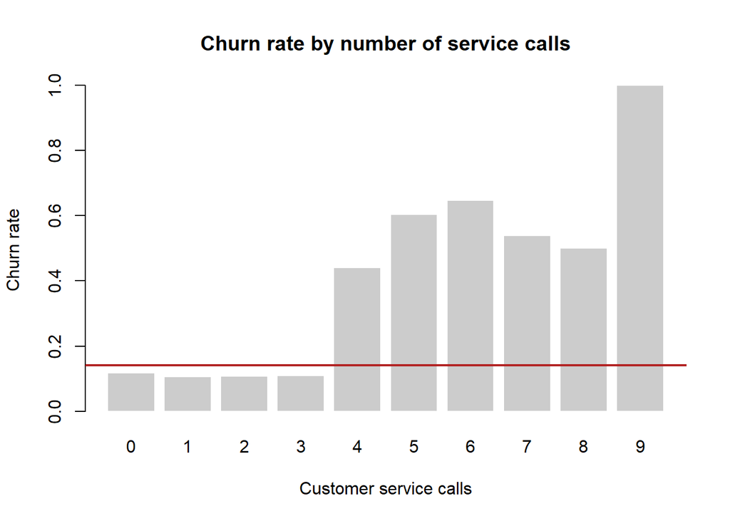

```r
rate <- tapply(churn$churn == "yes", churn$number_customer_service_calls, mean)

barplot(rate, col = "grey80", border = "white",
        xlab = "Customer service calls", ylab = "Churn rate",
        main = "Churn rate by number of service calls")
abline(h = mean(churn$churn == "yes"), col = "firebrick", lwd = 2)
```

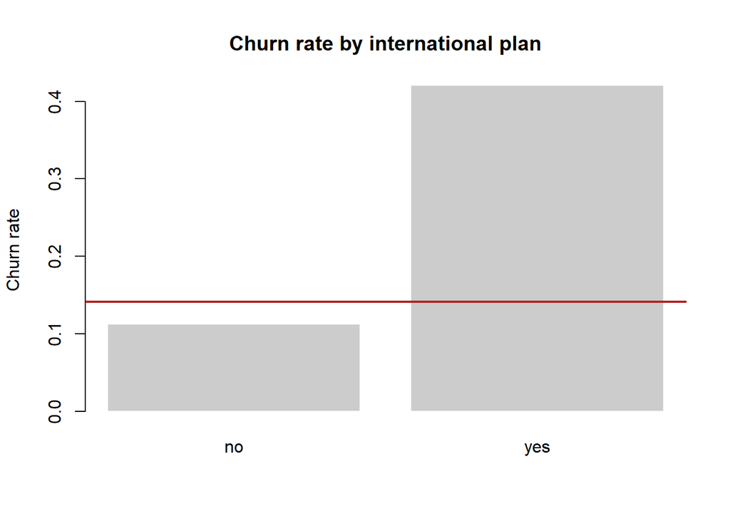

```r
rate.int <- tapply(churn$churn == "yes", churn$international_plan, mean)

barplot(rate.int, col = "grey80", border = "white",
        ylab = "Churn rate", main = "Churn rate by international plan")
abline(h = mean(churn$churn == "yes"), col = "firebrick", lwd = 2)
```

```r
table(churn$number_customer_service_calls)
```

```
##
##    0    1    2    3    4    5    6    7    8    9
## 1023 1786 1127  665  252   96   34   13    2    2
```

Before fitting any model, the plots check whether the predictors carry a signal at all. The red line is the overall churn rate (14.1%), the reference every bar has to be compared with. Churn is flat at about 11% for 0 to 3 service calls and jumps to about 44% at 4 calls and above 60% at 5 and 6 calls (customers with 4 or more calls churn at 50% versus 11% for the others); only 17 customers have 7 or more calls, so those bars are noisy. Customers with an international plan churn at 42%, compared with 11% without one, so both variables look informative before any model is fitted.

# 2. The benchmark: compared to what?

```r
table(churn$churn)
```

```
##
##  yes   no
##  707 4293
```

```r
prop.table(table(churn$churn))
```

```
##
##    yes     no
## 0.1414 0.8586
```

```r
mean(churn$churn == "yes")
```

```
## [1] 0.1414
```

```r
churn$churn <- factor(churn$churn, levels = c("no", "yes")) # glm models the 2nd level -> "yes" last
levels(churn$churn)
```

```
## [1] "no"  "yes"
```

```r
contrasts(churn$churn)
```

```
##     yes
## no    0
## yes   1
```

```r
1 - max(table(churn$churn)) / length(churn$churn)
```

```
## [1] 0.1414
```

A model that always predicts “no” is wrong for 14.1% of all customers (13.6% on the test set used later), so it reaches an accuracy of about 86% without finding a single churner. Every model below has to beat this error rate, and since an error rate alone rewards ignoring the churners, it is also judged by sensitivity.

# 3. Logistic regression on a train/test split

The model is fitted to the training data, so it has already “seen” these customers and the training error is optimistically low, in particular for flexible models, because it also rewards fitting noise. Therefore, the training error does not tell us how the model performs on new customers, only the error on held-out test data estimates this.

```r
set.seed(2)

n     <- nrow(churn)
train <- sample(n, n/2)
test.y <- churn$churn[- train]
table(test.y)
```

```
## test.y
##   no  yes
## 2161  339
```

```r
logit.fit <- glm(churn ~ ., family = binomial, data = churn[train, ])

summary(logit.fit)
```

```
##
## Call:
## glm(formula = churn ~ ., family = binomial, data = churn[train,
##     ])
##
## Coefficients:
##                                 Estimate Std. Error z value Pr(>|z|)
## (Intercept)                   -8.3551298  0.8102668 -10.312  < 2e-16 ***
## account_length                 0.0010069  0.0016215   0.621 0.534595
## international_planyes          2.2071946  0.1724604  12.798  < 2e-16 ***
## voice_mail_planyes            -1.6762077  0.6875146  -2.438 0.014766 *
## number_vmail_messages          0.0146055  0.0218960   0.667 0.504747
## total_day_minutes              0.0150844  0.0012921  11.675  < 2e-16 ***
## total_day_calls                0.0020233  0.0032569   0.621 0.534447
## total_eve_minutes              0.0058938  0.0013180   4.472 7.75e-06 ***
## total_eve_calls               -0.0027426  0.0032663  -0.840 0.401106
## total_night_minutes            0.0032768  0.0012610   2.599 0.009362 **
## total_night_calls              0.0008067  0.0032028   0.252 0.801136
## total_intl_minutes             0.0907633  0.0237754   3.818 0.000135 ***
## total_intl_calls              -0.0440332  0.0271339  -1.623 0.104630
## number_customer_service_calls  0.4676562  0.0460237  10.161  < 2e-16 ***
## ---
## Signif. codes:  0 '***' 0.001 '**' 0.01 '*' 0.05 '.' 0.1 ' ' 1
##
## (Dispersion parameter for binomial family taken to be 1)
##
##     Null deviance: 2089.1  on 2499  degrees of freedom
## Residual deviance: 1602.7  on 2486  degrees of freedom
## AIC: 1630.7
##
## Number of Fisher Scoring iterations: 6
```

```r
z <- coef(summary(logit.fit))[, "z value"]
sort(abs(z), decreasing = TRUE)
```

```
##         international_planyes             total_day_minutes
##                    12.7982710                    11.6746062
##                   (Intercept) number_customer_service_calls
##                    10.3115790                    10.1612104
##             total_eve_minutes            total_intl_minutes
##                     4.4718884                     3.8175260
##           total_night_minutes            voice_mail_planyes
##                     2.5985422                     2.4380685
##              total_intl_calls               total_eve_calls
##                     1.6228123                     0.8396481
##         number_vmail_messages               total_day_calls
##                     0.6670396                     0.6212325
##                account_length             total_night_calls
##                     0.6210068                     0.2518774
```

```r
exp(coef(logit.fit)["international_planyes"])
```

```
## international_planyes
##              9.090179
```

The coefficient of international_planyes is 2.21, and exp(2.21) = 9.09. Holding all other variables fixed, customers with an international plan have 9.09 times the odds of churning (the odds are p / (1 - p), so this is not nine times the probability).

```r
logit.probs <- predict(logit.fit, churn[-train, ], type = "response")
logit.pred  <- factor(ifelse(logit.probs > 0.5, "yes", "no"),
                      levels = levels(churn$churn))

table(Predicted = logit.pred, True = test.y)
```

```
##          True
## Predicted   no  yes
##       no  2099  272
##       yes   62   67
```

```r
mean(logit.pred != test.y)
```

```
## [1] 0.1336
```

```r
mean(test.y == "yes")
```

```
## [1] 0.1356
```

```r
cm <- table(Predicted = logit.pred, True = test.y)
cm["yes", "yes"] / sum(cm[, "yes"])
```

```
## [1] 0.1976401
```

```r
cm["no", "no"]     / sum(cm[, "no"])
```

```
## [1] 0.9713096
```

```r
confusionMatrix(logit.pred, test.y, positive = "yes")
```

```
## Confusion Matrix and Statistics
##
##           Reference
## Prediction   no  yes
##        no  2099  272
##        yes   62   67
##
##                Accuracy : 0.8664
##                  95% CI : (0.8524, 0.8795)
##     No Information Rate : 0.8644
##     P-Value [Acc > NIR] : 0.3989
##
##                   Kappa : 0.2287
##
##  Mcnemar's Test P-Value : <2e-16
##
##             Sensitivity : 0.1976
##             Specificity : 0.9713
##          Pos Pred Value : 0.5194
##          Neg Pred Value : 0.8853
##              Prevalence : 0.1356
##          Detection Rate : 0.0268
##    Detection Prevalence : 0.0516
##       Balanced Accuracy : 0.5845
##
##        'Positive' Class : yes
##
```

On this split the logistic regression has a test error of 13.4% against 13.6% for the benchmark, an improvement of only 0.2 percentage points. Its most frequent mistake is missing churners: of the 339 churners in the test set, 272 were not found (sensitivity 20%), while only 62 loyal customers were flagged by mistake (specificity 97%). At a threshold of 0.5 the model only says “yes” when it is very sure, which rarely happens with a churn rate of 14%. This is the more expensive kind of mistake identified in section 1. Because this is a single split, the size of the improvement is checked in section 5.

# 4. Lasso logistic regression

Instead of only minimizing the loss, the lasso adds a penalty. This penalty shrinks the coefficients towards zero, which reduces their variance. Because it uses absolute values, some coefficients become exactly zero, so the lasso also selects variables. Lambda controls the strength of the penalty: lambda = 0 gives the ordinary fit, and a large lambda leaves only a few variables in the model. Lambda is chosen by 10-fold cross-validation on the training rows only, so the test set is not touched. I used lambda.1se, the largest lambda whose cross-validation error is within one standard error of the minimum, because it gives a simpler model that is about as good as the best one.

```r
x <- model.matrix(churn ~ ., data = churn)[, -1] # glmnet needs a numeric matrix; [, -1] drops the intercept column
y <- churn$churn
dim(x)
```

```
## [1] 5000   13
```

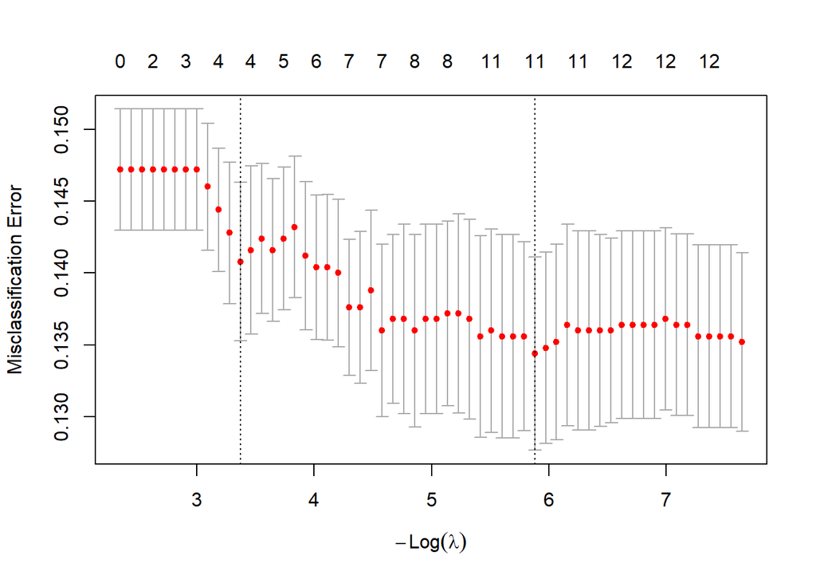

```r
set.seed(2) # CV folds are random
cv.fit <- cv.glmnet(x[train, ], y[train], family = "binomial", alpha = 1,
                    type.measure = "class")    # CV error = misclassification rate
plot(cv.fit)
```

```r
cv.fit$lambda.min
```

```
## [1] 0.002792859
```

```r
cv.fit$lambda.1se
```

```
## [1] 0.03443167
```

```r
coef(cv.fit, s = "lambda.1se")
```

```
## 14 x 1 sparse Matrix of class "dgCMatrix"
##                                 lambda.1se
## (Intercept)                   -3.640948353
## account_length                 .
## international_planyes          1.258294769
## voice_mail_planyes            -0.188563587
## number_vmail_messages          .
## total_day_minutes              0.007492204
## total_day_calls                .
## total_eve_minutes              .
## total_eve_calls                .
## total_night_minutes            .
## total_night_calls              .
## total_intl_minutes             .
## total_intl_calls               .
## number_customer_service_calls  0.205687263
```

```r
sum(coef(cv.fit, s = "lambda.1se")[-1] != 0)
```

```
## [1] 4
```

```r
round(cbind(glm   = coef(logit.fit),
            lasso = coef(cv.fit, s = "lambda.1se")[, 1]), 4)
```

```
##                                   glm   lasso
## (Intercept)                   -8.3551 -3.6409
## account_length                 0.0010  0.0000
## international_planyes          2.2072  1.2583
## voice_mail_planyes            -1.6762 -0.1886
## number_vmail_messages          0.0146  0.0000
## total_day_minutes              0.0151  0.0075
## total_day_calls                0.0020  0.0000
## total_eve_minutes              0.0059  0.0000
## total_eve_calls               -0.0027  0.0000
## total_night_minutes            0.0033  0.0000
## total_night_calls              0.0008  0.0000
## total_intl_minutes             0.0908  0.0000
## total_intl_calls              -0.0440  0.0000
## number_customer_service_calls  0.4677  0.2057
```

```r
lasso.probs <- predict(cv.fit, x[-train, ], s = "lambda.1se", type = "response")
lasso.probs <- as.numeric(lasso.probs)          # predict() returns a MATRIX here
lasso.pred  <- factor(ifelse(lasso.probs > 0.5, "yes", "no"), levels = levels(y))

table(Predicted = lasso.pred, True = test.y)
```

```
##          True
## Predicted   no  yes
##       no  2154  330
##       yes    7    9
```

```r
mean(lasso.pred != test.y)
```

```
## [1] 0.1348
```

```r
cm.lasso <- table(Predicted = lasso.pred, True = test.y)
cm.lasso["yes", "yes"] / sum(cm.lasso[, "yes"])
```

```
## [1] 0.02654867
```

```r
cm.lasso["no", "no"]     / sum(cm.lasso[, "no"])
```

```
## [1] 0.9967608
```

```r
confusionMatrix(lasso.pred, test.y, positive = "yes")
```

```
## Confusion Matrix and Statistics
##
##           Reference
## Prediction   no  yes
##        no  2154  330
##        yes    7    9
##
##                Accuracy : 0.8652
##                  95% CI : (0.8512, 0.8784)
##     No Information Rate : 0.8644
##     P-Value [Acc > NIR] : 0.4679
##
##                   Kappa : 0.039
##
##  Mcnemar's Test P-Value : <2e-16
##
##             Sensitivity : 0.02655
##             Specificity : 0.99676
##          Pos Pred Value : 0.56250
##          Neg Pred Value : 0.86715
##              Prevalence : 0.13560
##          Detection Rate : 0.00360
##    Detection Prevalence : 0.00640
##       Balanced Accuracy : 0.51165
##
##        'Positive' Class : yes
##
```

At lambda.1se (0.034) the lasso keeps four of the 13 predictors: international_plan, voice_mail_plan, total_day_minutes and number_customer_service_calls, which are also among the most significant in the glm. Its test error on this split is 13.5%, slightly above the glm (13.4%) and just below the benchmark (13.6%). Its sensitivity is only 2.7% (9 of 339 churners): the shrinkage pulls all predicted probabilities towards the base rate of 14%, so almost none exceeds 0.5. The lasso therefore does not improve on the glm here; whether the difference is real is checked in section 5.

# 5. How much can one split be trusted?

Over 100 random 50/50 splits the test error of the logistic regression ranges from 12.4% to 14.7%, so a single split can move the result by about as much as the gap between the models. Comparing the models on the same splits removes this shared noise: a split that happens to put few hard-to-predict customers into the test set lowers the error of every model, but the difference between two models on the same split does not depend on how “easy” the split was.

```r
# The split is an argument, not drawn inside, so that all three methods are evaluated on exactly the same test customers.
test.errors <- function(train) {
  test.y <- churn$churn[-train]

  # (a) benchmark
  bench <- mean(test.y == "yes")

  # (b) logistic regression
  fit   <- glm(churn ~ ., family = binomial, data = churn[train, ])
  probs <- predict(fit, churn[-train, ], type = "response")
  pred  <- factor(ifelse(probs > 0.5, "yes", "no"), levels = levels(y))
  logit <- mean(pred != test.y)

  # (c) lasso
  cv    <- cv.glmnet(x[train, ], y[train], family = "binomial", alpha = 1, type.measure = "class")
  probs <- as.numeric(predict(cv, x[-train, ], s = "lambda.1se", type = "response"))
  pred  <- factor(ifelse(probs > 0.5, "yes", "no"), levels = levels(y))
  lasso <- mean(pred != test.y)

  c(benchmark = bench, logit = logit, lasso = lasso)
}

set.seed(2)
test.errors(train) # sanity check: must reproduce the results of sections 3 and 4
```

```
## benchmark     logit     lasso
##    0.1356    0.1336    0.1348
```

```r
set.seed(2)
errors <- replicate(100, test.errors(sample(n, n/2)))
dim(errors)
```

```
## [1]   3 100
```

```r
rowMeans(errors)
```

```
## benchmark     logit     lasso
##  0.141204  0.134848  0.139516
```

```r
apply(errors, 1, sd)
```

```
##   benchmark       logit       lasso
## 0.005069376 0.004482164 0.005460690
```

```r
summary(t(errors))
```

```
##    benchmark          logit            lasso
##  Min.   :0.1268   Min.   :0.1236   Min.   :0.1260
##  1st Qu.:0.1380   1st Qu.:0.1316   1st Qu.:0.1360
##  Median :0.1404   Median :0.1350   Median :0.1392
##  Mean   :0.1412   Mean   :0.1348   Mean   :0.1395
##  3rd Qu.:0.1441   3rd Qu.:0.1372   3rd Qu.:0.1428
##  Max.   :0.1540   Max.   :0.1468   Max.   :0.1540
```

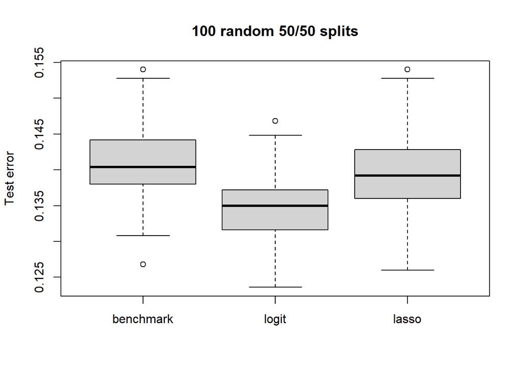

```r
boxplot(t(errors), ylab = "Test error", main = "100 random 50/50 splits")
```

```r
mean(errors["lasso", ] < errors["logit", ])
```

```
## [1] 0.16
```

```r
mean(errors["logit", ] < errors["benchmark", ])
```

```
## [1] 0.93
```

```r
summary(errors["lasso", ] - errors["logit", ])
```

```
##      Min.   1st Qu.    Median      Mean   3rd Qu.      Max.
## -0.006000  0.000700  0.004800  0.004668  0.008000  0.014000
```

On average the test error is 14.1% for the benchmark, 13.5% for the logistic regression and 14.0% for the lasso. The logistic regression beats the benchmark on 93% of the splits, but by only about 0.6 percentage points on average, which is comparable to the standard deviation of a single split (about 0.5). The lasso beats the logistic regression on only 16% of the splits and is worse by about 0.5 percentage points on average. I can therefore claim that the logistic regression is slightly but consistently better than always predicting “no”, and that the lasso brings no improvement here. I cannot claim a large improvement, and the result applies to this error measure at a threshold of 0.5.

# 6. Ranking customers instead of classifying at 0.5

The model gives every customer a probability of churning, and a threshold turns it into “yes” or “no”. The ROC curve shows, for every possible threshold, which share of the churners is found (sensitivity) and which share of the loyal customers is flagged by mistake (1 - specificity). It therefore shows the whole trade-off, whereas an error rate describes only one threshold (here 0.5). The AUC is the area under this curve. It equals the probability that a randomly chosen churner gets a higher predicted probability than a randomly chosen non-churner: 0.5 means guessing, 1 means a perfect ranking.

```r
logit.roc <- roc(test.y, logit.probs, levels = c("no", "yes"), direction = "<") # levels = control, case; otherwise the curve is mirrored
lasso.roc <- roc(test.y, lasso.probs, levels = c("no", "yes"), direction = "<")
auc(logit.roc)
```

```
## Area under the curve: 0.8193
```

```r
auc(lasso.roc)
```

```
## Area under the curve: 0.8009
```

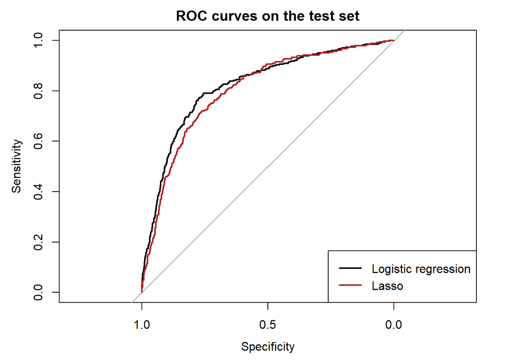

```r
plot(logit.roc, col = "black", main = "ROC curves on the test set")
plot(lasso.roc, col = "firebrick", add = TRUE)
legend("bottomright", legend = c("Logistic regression", "Lasso"),
       col = c("black", "firebrick"), lwd = 2)
```

```r
low.pred <- factor(ifelse(logit.probs > 0.2, "yes", "no"), levels = levels(y)) # lower threshold chosen a priori, not tuned on the test set
cm.low   <- table(Predicted = low.pred, True = test.y)
cm.low
```

```
##          True
## Predicted   no  yes
##       no  1809  113
##       yes  352  226
```

```r
mean(low.pred != test.y)
```

```
## [1] 0.186
```

```r
cm.low <- table(Predicted = low.pred, True = test.y)
cm.low["yes", "yes"] / sum(cm.low[, "yes"])
```

```
## [1] 0.6666667
```

```r
cm.low["no", "no"]     / sum(cm.low[, "no"])
```

```
## [1] 0.8371124
```

```r
confusionMatrix(low.pred, test.y, positive = "yes")
```

```
## Confusion Matrix and Statistics
##
##           Reference
## Prediction   no  yes
##        no  1809  113
##        yes  352  226
##
##                Accuracy : 0.814
##                  95% CI : (0.7982, 0.8291)
##     No Information Rate : 0.8644
##     P-Value [Acc > NIR] : 1
##
##                   Kappa : 0.3884
##
##  Mcnemar's Test P-Value : <2e-16
##
##             Sensitivity : 0.6667
##             Specificity : 0.8371
##          Pos Pred Value : 0.3910
##          Neg Pred Value : 0.9412
##              Prevalence : 0.1356
##          Detection Rate : 0.0904
##    Detection Prevalence : 0.2312
##       Balanced Accuracy : 0.7519
##
##        'Positive' Class : yes
##
```

The AUC is 0.82 for the logistic regression and 0.80 for the lasso, so both rank customers similarly well even though the lasso finds almost no churners at a threshold of 0.5. Lowering the threshold to 0.2 (chosen before looking at the test error, not tuned on it) raises the sensitivity of the logistic regression from 20% to 67% and lowers the specificity from 97% to 84%; the model then flags 578 instead of 129 customers and the test error rises from 13.4% to 18.6%. A threshold of 0.2 is worth it if one missed churner costs clearly more than one wasted retention offer. The right threshold depends on this cost ratio, which is not in the data.

# 7. Conclusion and limitations

**Main result**

The logistic regression beat the “always no” benchmark on 93% of 100 random splits, but only by about 0.6 percentage points in test error (13.5% vs. 14.1%), and the lasso did not improve on it.

**What I would do with more time**

With more time I would choose the threshold from the real cost of a retention offer and of a lost customer instead of 0.5, run the lasso with the charge columns, state and area_code included, and add a variable for “4 or more service calls”, since the churn rate jumps at that point.

**Limitations**

The data are a single, artificial data set (according to the package documentation), so the results may not hold for real customers; there is no external validation and no cost information; the threshold of 0.2 is an illustration rather than a tuned choice; and the models were compared only with 50/50 splits and error rate, sensitivity and AUC.